# 데이터 분석 보고서 만들기(큰제목)

## R Markdown이란? (부제목)

```r
library(ggplot2)
library(gapminder)
library(dplyr)
```

마크다운 문법으로 코드를 작성해 HTML로 변환할 수 있습니다. R마크다운을 이용하면 분석 과정과 결과를 기술할 수 있기 때문에 **재현가능성**을 갖춘 *데이터 분석 보고서(이탤릭체)*를 만들 수 있습니다.

ex01~10까지 해결. 코드 파일 본인이름.R 본인이름.Rmd ex01.png~ex10.png 13개 파일 압축해서 제출

### 연습문제 1

datasets::cars데이터 셋을 이용하여 속도에 대한 제동거리의 산점도와 적합도(신뢰구간 그래프)를 나타내시오(단, 속도가 5부터 20까지 제동거리 0부터 100까지만 그래프에 나타 냄).

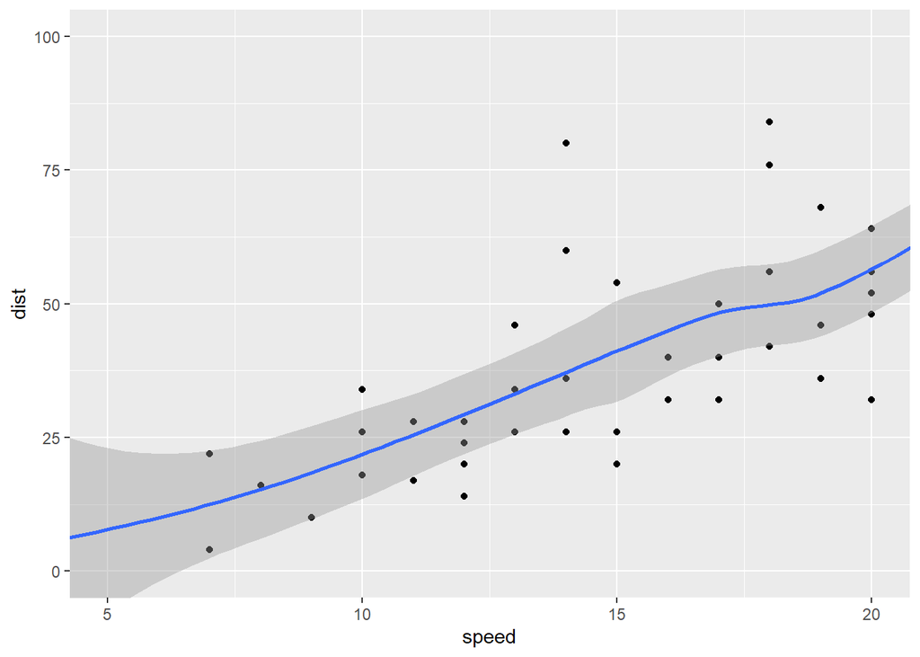

```r
ggplot(cars,aes(x=speed,y=dist))+
  coord_cartesian(xlim=c(5,20),ylim=c(0,100))+
  geom_point()+
  geom_smooth()
```

### 연습문제 2

gapminder::gapminder 데이터 셋을 이용하여 1인당국내총생산에 대한 기대수명의 산점 도를 대륙별 다른 색으로 나타내시오.

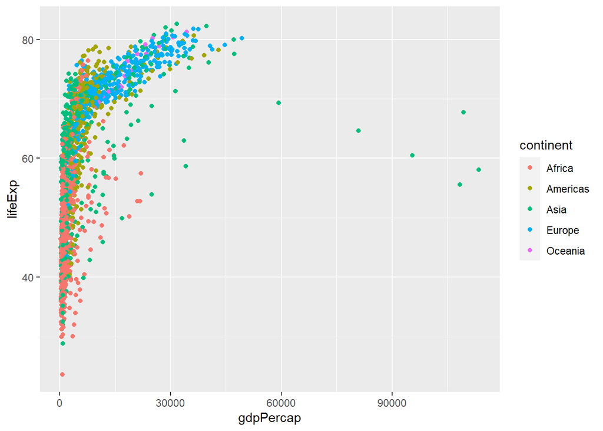

```r
library(ggplot2)
ggplot(gapminder,aes(x=gdpPercap,y=lifeExp,col=continent))+
  geom_point()
```

### 연습문제 3

gapminder::gapminder 데이터 셋을 이용하여 기대 수명이 70을 초과하는 데이터에 대해 대륙별 데이터 갯수

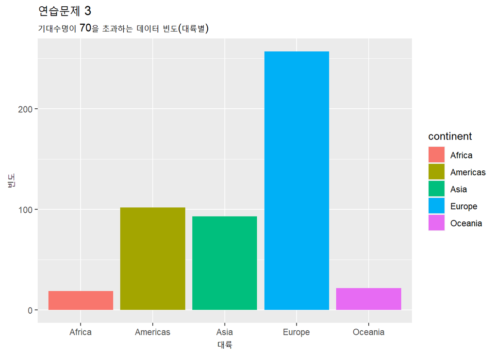

```r
library(ggplot2)
gapminder %>%
  filter(lifeExp>70) %>%
  group_by(continent) %>%
  summarise(n=n()) %>%
  ggplot(aes(x=continent,y=n,fill=continent))+
  geom_bar(stat='identity')+
  labs(title="연습문제 3",
       subtitle="기대수명이 70을 초과하는 데이터 빈도(대륙별)",
       x="대륙",y="빈도")
```

### 연습문제 4

gapminder::gapminder 데이터 셋을 이용하여 기대수명이 70을 초과하는 데이터에 대해 대륙별 나라 갯수.

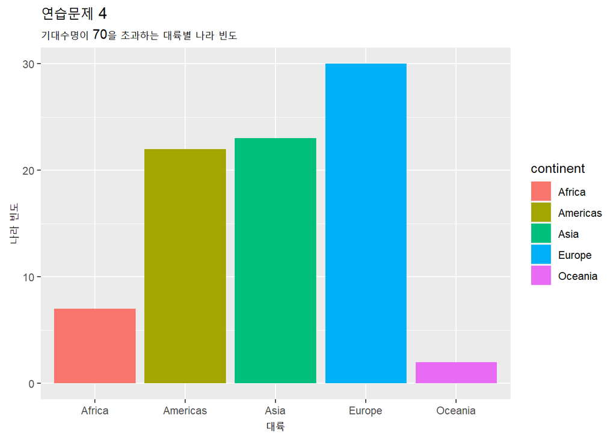

```r
library(ggplot2)
gapminder %>%
  filter(lifeExp>70) %>%
  group_by(continent,country) %>%
  summarise(n=n()) %>%
  group_by(continent) %>%
  summarise(n=n())%>%
  ggplot(aes(x=continent,y=n,fill=continent))+
  geom_col()+
  labs(title="연습문제 4",
       subtitle="기대수명이 70을 초과하는 대륙별 나라 빈도",
       x="대륙",y="나라 빈도")
```

### 연습문제 5

gapminder::gapminder 데이터 셋을 이용하여 대륙별 기대수명의 사분위수를 시각화

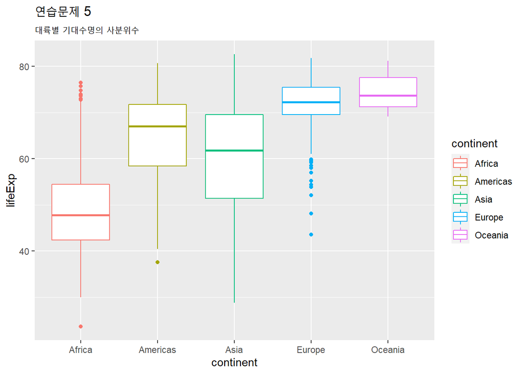

```r
ggplot(gapminder, aes(y=lifeExp, x=continent))  +
  geom_boxplot(aes(col=continent),fill='white')+
  labs(title="연습문제 5",
       subtitle="대륙별 기대수명의 사분위수")
```

### 연습문제 6

gapminder::gapminder 데이터 셋을 이용하여 년도별로 gdp와 기대수명과의 관계를 산점도를 그리고 대륙별 점의 색상을 달리 시각화

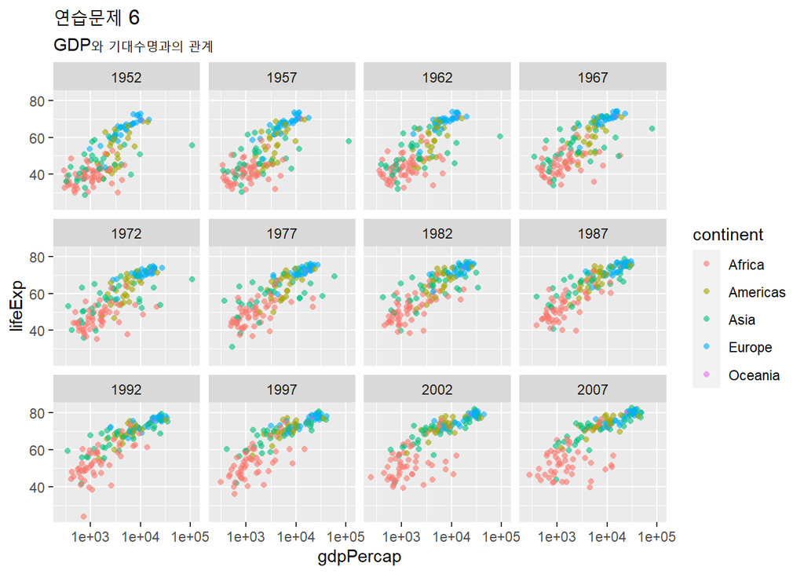

```r
ggplot(gapminder, aes(x=gdpPercap,y=lifeExp))  +
  geom_point(aes(col=continent),alpha=0.6,pch=16)+
  facet_wrap(~year)+
  scale_x_log10()+
  #coord_cartesian(xlim=c(5,10000))
  labs(title="연습문제 6",
       subtitle="GDP와 기대수명과의 관계",
       x="gdpPercap",y="lifeExp")
```

### 연습문제 7

gapminder::gapminder 데이터 셋에서 북한과 한국의 년도별 GDP 변화를 산점도로 시각 화하시오(북한:Korea, Dem. Rep. 한국:Korea, Rep. substr(str, start, end)함수 이용)

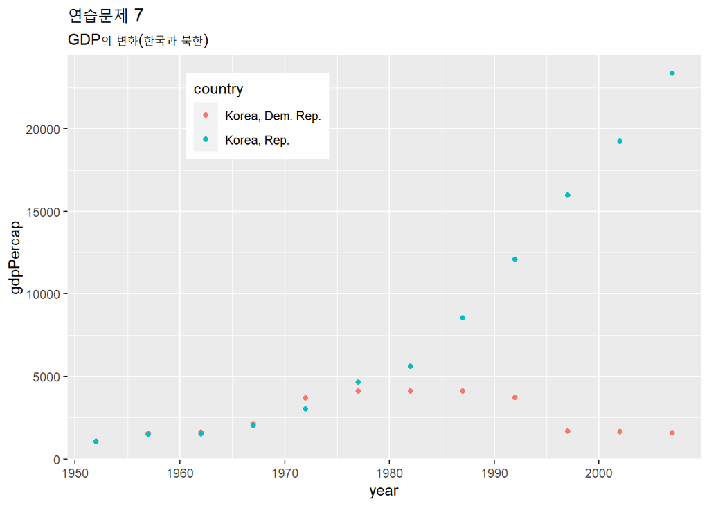

```r
gapminder %>%
  filter(substr(country, 1, 5) =='Korea') %>%
  ggplot(aes(x=year,y=gdpPercap))  +
  geom_point(aes(col=country),pch=16)+
  labs(title="연습문제 7",
       subtitle="GDP의 변화(한국과 북한)")+
  theme(legend.position = c(0.3,0.85))
```

### 연습문제 8

gapminder::gapminder 데이터 셋을 이용하여 한중일 4개국별 GDP 변화를 산점도와 추 세선으로 시각화 하시오.

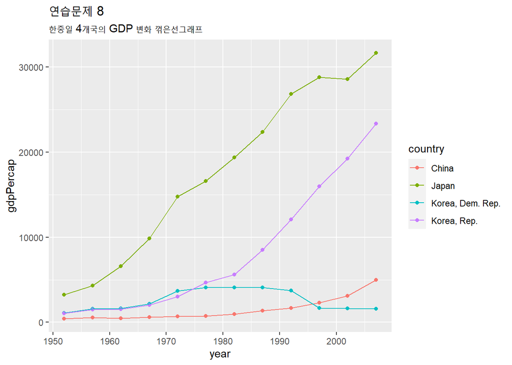

```r
gapminder %>%
  filter(substr(country, 1, 5) %in% c('Korea','China','Japan')) %>%
  ggplot(aes(x=year,y=gdpPercap))  +
  geom_point(aes(col=country),pch=16)+
  geom_line(mapping=aes(x=year,y=gdpPercap,group=country,color=country))+
  labs(title="연습문제 8",
       subtitle="한중일 4개국의 GDP 변화 꺾은선그래프 ")
```

### 연습문제 9

gapminder::gapminder 데이터 셋에서 한중일 4개국별 인구변화 변화를 산점도와 추세선 으로 시각화 하시오(scale_y_continuous(labels = scales::comma)추가시 우측처럼)

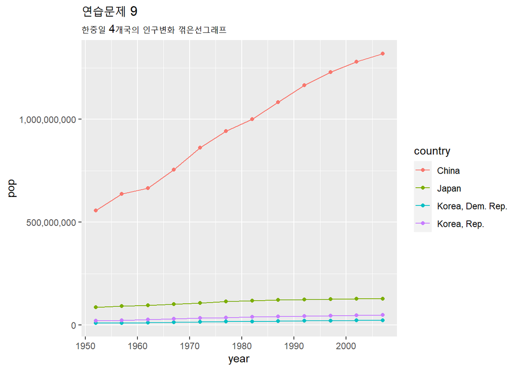

```r
gapminder %>%
  filter(substr(country, 1, 5) %in% c('Korea','China','Japan')) %>%
  ggplot(aes(x=year,y=pop))  +
  geom_point(aes(col=country),pch=16)+
  geom_line(mapping=aes(x=year,y=pop,group=country,color=country))+
  labs(title="연습문제 9",
       subtitle="한중일 4개국의 인구변화 꺾은선그래프 ")+
  scale_y_continuous(labels = scales::comma)
```

### 연습문제 10

ggplot2::economic 데이터 셋의 개인 저축률(psavert)가 시간에 따라 어떻게 변해 왔는지 알아보려 한다. 시간에 따른 개인 저축률의 변화를 나타낸 시계열 그래프와 추세선을 시각 화하시오

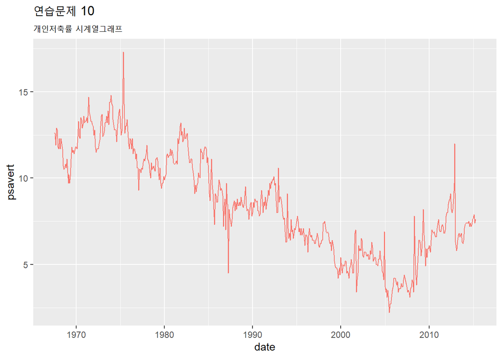

```r
economics %>%
  #filter(substr(country, 1, 5) %in% c('Korea','China','Japan')) %>%
  ggplot(aes(x=date,y=psavert))  +
  #geom_point(aes(col=country),pch=16)+
  geom_line(mapping=aes(x=date,y=psavert,color='red'))+
  labs(title="연습문제 10",
       subtitle="개인저축률 시계열그래프 ")+
  theme(legend.position ="none")
```